# Death Penalty as a Criminal Preventive

Cecilie Poulsen

Created 17th of December 2021, Updated 09 Januar 2022 10:28

This project is based on data provided by [Death Penalty Information Center](https://deathpenaltyinfo.org/executions/execution-database)

## **Loading libraries**

```r
library(tidyverse)
```

## **The meaning of this HTML**

This HTML document is made to visualize the connection between the reinstatement of the death penalty in USA in 1976 and the amount of homicides committed. The death penalty was reinstated as a criminal preventive mean, and it will obviously prevent inmates of the death row to further commit homicide. But I seek to figure out whether it will prevent potential homicides from happening, because the potential murderer is aware that the action of homicide can cause a death sentence.

## **Loading the datasets**

**Firstly, I’ll load the data set from the Death Penalty Information Center which shows homicides through time in the US. This is done by using the function: read_csv**

```r
library(readr)
Murder_Rates_By_State_Full_Data_clean <- read_csv("Dataset_DeathPenaltyInformationCenter/Murder_Rates_By_State_Full_Data_clean.csv")
```

**Now I’ll load 2 datasets for the states Florida (death penalty is legal) and New York (death penalty is not legal) for comparison**

```r
library(readr)
Murder_Rates_In_Florida_clean <- read_csv("Dataset_DeathPenaltyInformationCenter/Murder_Rates_In_Florida_clean.csv")
library(readr)
Murder_Rates_In_NewYork_clean <- read_csv("Dataset_DeathPenaltyInformationCenter/Murder_Rates_In_NewYork_clean.csv")
```

**My own data set**  
For some reason my data set can not seem to become comma separated when using Microsoft Excel, only semicolon separated, therefore I will use the read_delim function to load my own data set, and set the delim to a semicolon.

```r
library(readr)
executions_per_year_in_selected_states <- read_delim("own_dataset/test_executions_per_year_selected_states.csv",
    delim = ";", escape_double = FALSE, trim_ws = TRUE)
```

## **Executions per year in all states**

The graph below shows executions per year in all states from 1977 till 2021

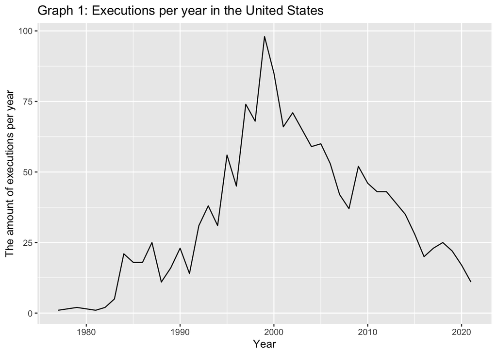

```r
ggplot(data = executions_per_year_in_selected_states)+
  geom_line(mapping = aes(x = execution_year, y = amount_execution_per_year))+
  labs(x = "Year",
       y = "The amount of executions per year",
       title = "Graph 1: Executions per year in the United States")+
  theme(legend.position = "bottom")
```

As we can see in the graph above it is very obvious that the amount of executions peaks around 1999. There is a general increase in executions in the period from 1977 to 1999. In 1999 the number decreases drastically, and that trend continues (and still is).

**Executions in Florida**

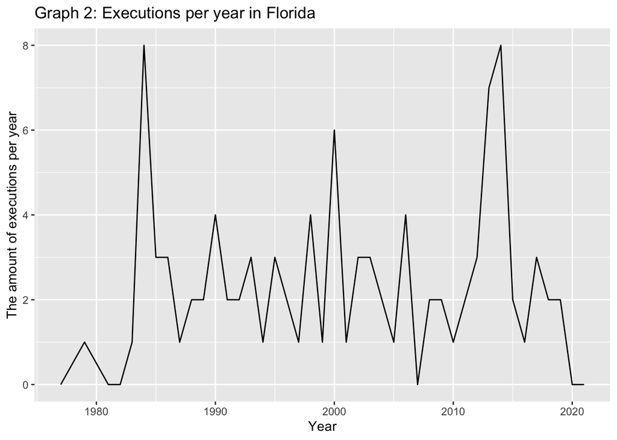

```r
executions_per_year_in_selected_states%>%
  ggplot(mapping = aes(x = execution_year, y = florida_amount_execution))+
  geom_line()+
  labs(x = "Year",
       y = "The amount of executions per year",
       title = "Graph 2: Executions per year in Florida")+
  theme(legend.position = "bottom")
```

If we take a look at the state of Florida the trend is much more instabil and shifting. This graph peaks 2 times: 1984 and 2014. But almost every year since 1977 (with a few exceptions) there is an execution.

## **Murder rates in all of USA**

Now we will take a look at the murder rates in all of the US:

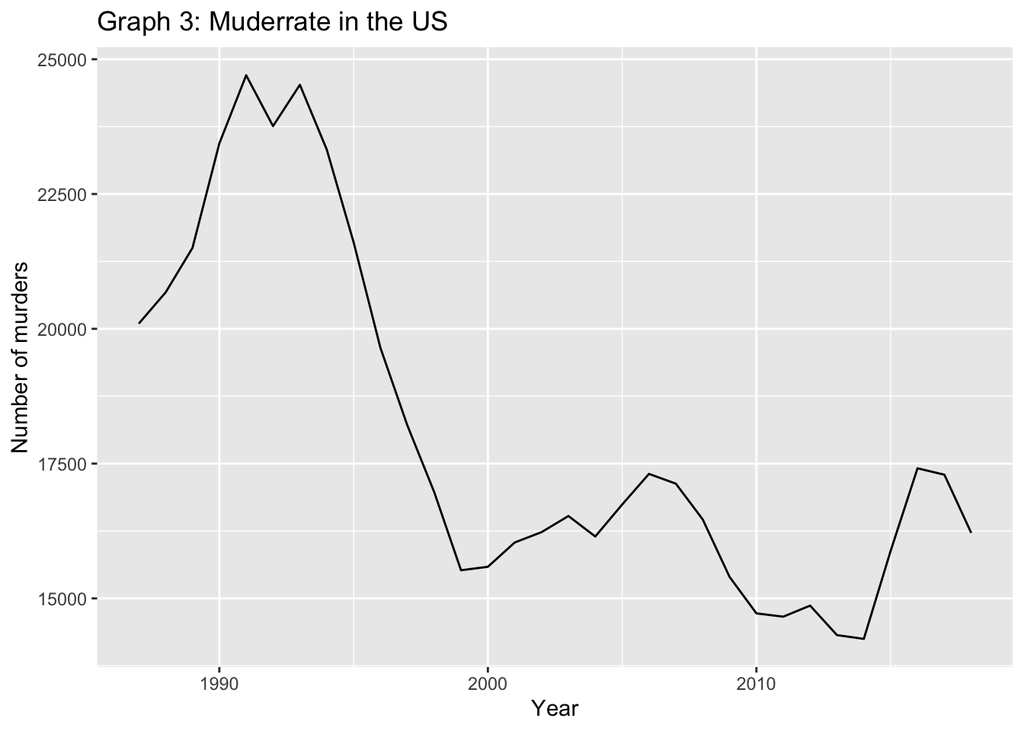

```r
Murder_Rates_By_State_Full_Data_clean %>%
  ggplot(mapping = aes(x=`Year of Year`, y= `Number of Murders`))+
  geom_line()+
    labs(x = "Year",
       y = "Number of murders",
       title = "Graph 3: Muderrate in the US")+
  theme(legend.position = "bottom")
```

**Murder rates in Florida vs New York**  
Now we will take a look at the two states of Florida and New York. Florida is one of the states with the highest amount of executions per year, and it is still legal to execute someone who has committed homicide. In contrast to that the state of New York does not have the death penalty as a mean of punishment for homicide. Therefore, these two states will be good for comparison.

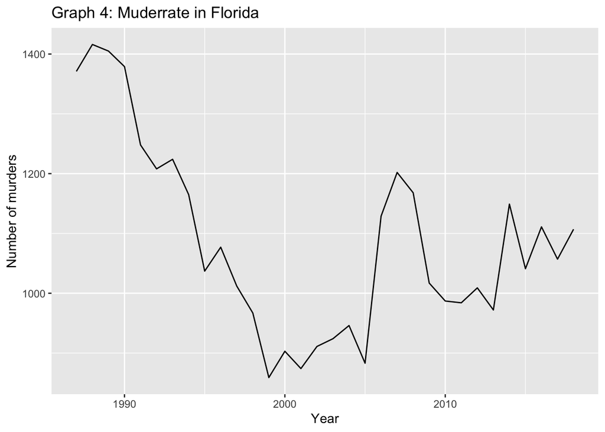

```r
Murder_Rates_In_Florida_clean%>%
  ggplot(mapping = aes(x=`Year of Year`,y=`Number of Murders`))+
  geom_line()+
      labs(x = "Year",
       y = "Number of murders",
       title = "Graph 4: Muderrate in Florida")+
  theme(legend.position = "bottom")
```

It is clear to see that the amounts of murders per year increase and decrease all the time. But, since 1987 the homicide rate has generally decreased. The trend peaks in 1988 and then decreases drastically until the millennium where it begins to increase a little again.

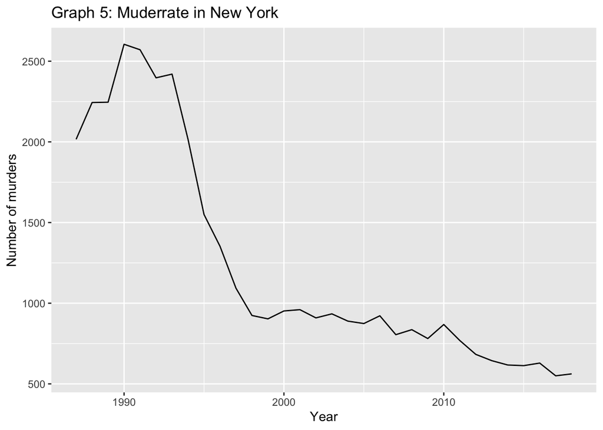

```r
Murder_Rates_In_NewYork_clean%>%
  ggplot(mapping = aes(x=`Year of Year`,y=`Number of Murders`))+
  geom_line()+
      labs(x = "Year",
       y = "Number of murders",
       title = "Graph 5: Muderrate in New York")+
  theme(legend.position = "bottom")
```

If we now take a look at the amount of homicides in the state of New York, we can actually see a pretty drastic decrease. The trend peaks in 1990, and then decreases to a little over 500 homicides in 2018. In contrast to the peak in 1990 where the number is around 2600.

## **Conclusion**

In conclusion we can say 3 things:

The amount of homicides has decreased in states with and without the death penalty as a mean of punishment.

The amount of executions has decreased in of the US

But this does not mean that fear of the death penalty is the reason for the decreasing number of homicides. If we take a look at the two states I used for comparison: both Florida and New York have a decreasing number of homicides, and that must mean that the death does not affect the amount of homicides committed. This is simply because of 2 reasons:

New York does not use the death penalty as a punishment, and still has lower homicide rate than Florida

Executions is still happening in Florida, and the homicide rate is still higher than the state of New York

To sum up: the death penalty does not work as a criminal preventive mean, and therefore does not (according to the trends) stop a potential murderer from committing homicide.